# Analisis cruceros Cartagena de Indias

# Contextualización

El siguiente análisis busca entender de manera general, la industria de los cruceros en la ciudad de Cartagena. Para ello, se busca información existente en la web y se apalanca dicha información con técnicas de captura de datos online.

El puerto de Cartagena lo administra el grupo “GRUPO PUERTO DE CARTAGENA”, que hace parte de la sociedad portuaria de Cartagena -empresas de infraestructura-, la cual fue fundada en 1993. Tenga presente que, para realizar entonces un correcto análisis del sector de los cruceros en la ciudad, se ha de conocer de manera general el contexto de la industria.

El puerto de Cartagena es un punto marítimo que atiende diferentes tipos de embarcaciones. En particular se tiene información para los años 2021 al 2022. Cabe destacar los efectos de la pandemia por COVID-19 han afectado significativamente los datos existentes, por tanto, los análisis predictivos aquí presente son meramente descriptivos. Se toman datos para el análisis exploratorio.

## Comparativa de puertos

El puerto de Cartagena de Indias en comparativa con los demás puertos de la zona, es el más importante en terminos de alcances economicos, de operación y demás.

La siguiente tabla adjunta, muestra la cantidad de embarcaciones que llegan en los tres puertos, esto; categorizado por año.

[output not shown]

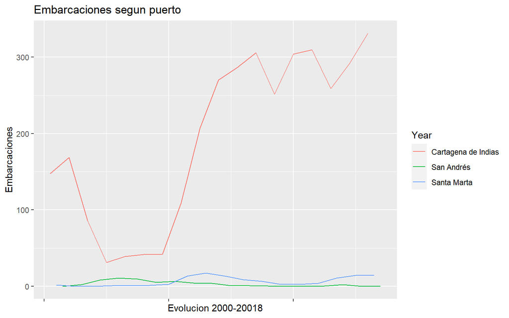

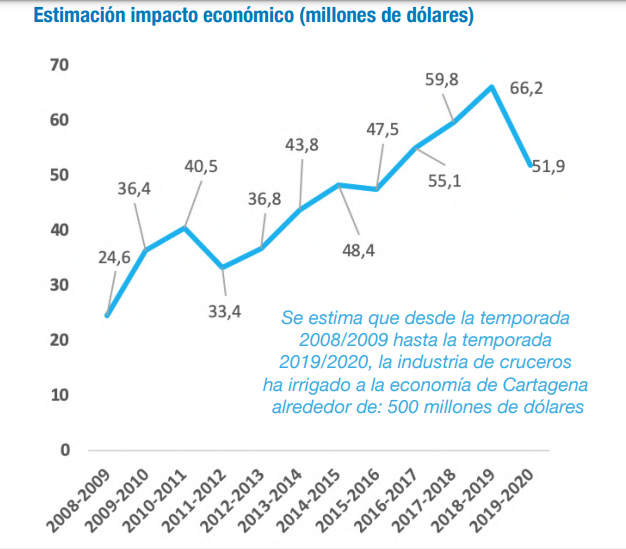

El anterior grafico muestra el desempeño económico (en millones de dólares americanos) en el histórico de los datos recolectados. Nótese que los valores se encontraban en incremento hasta antes de pandemia. Se adjunta un gráfico exploratorio del histórico de los datos de turismo y comercio.

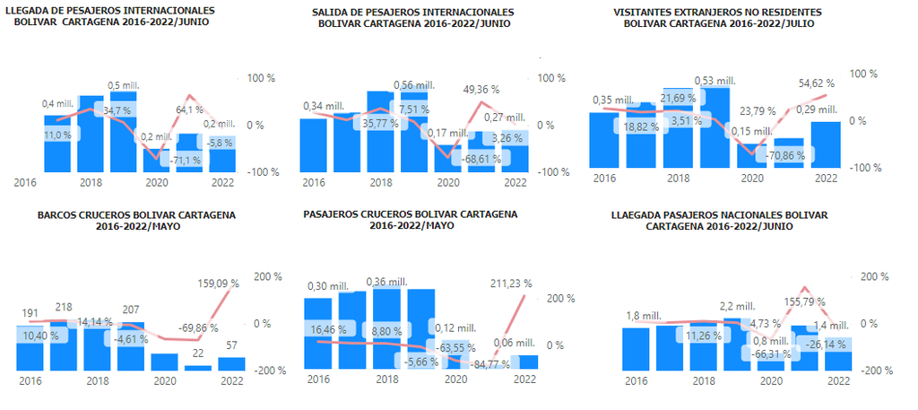

Para cada uno de los gráficos, se tiene en rosa, la línea de % de crecimiento/decrecimiento respecto al año anterior.

Las barras representan los valores asociados a la variable medida.

# Análisis generales

Un primer análisis indiscriminado de los años es del número total de pasajeros por empresas que brindan los servicios de turismo en cruceros.

## Información por cruceros

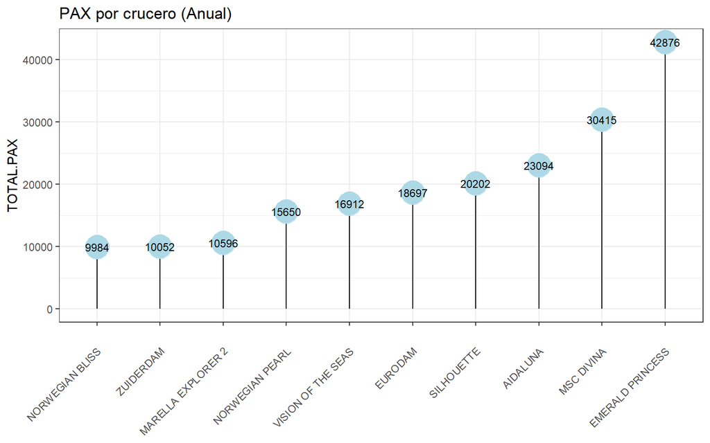

El grafico anterior muestra información de cruceros que brindan servicio en el puerto de Cartagena. Se podría pensar que existen tres tipos de servicios. el primero, dado por empresas que manejan un menor número de pasajeros anualmente (aproximadamente diez mil pasajeros). En esta categoría se encuentran NORWEGIAN BLISS, ZUIDERDAM, MARELLA EXPLLORER 2.

Luego se encuentran los de tamaño medio, que podrían transportar anualmente hasta 20 mil pasajeros.

Y finalmente, los más grandes, que según los datos; anualmente transportan más de 20 mil pasajeros, hasta 40.000; siendo este último el EMERALD PRINCESS.

## Total de pasajeros por mes

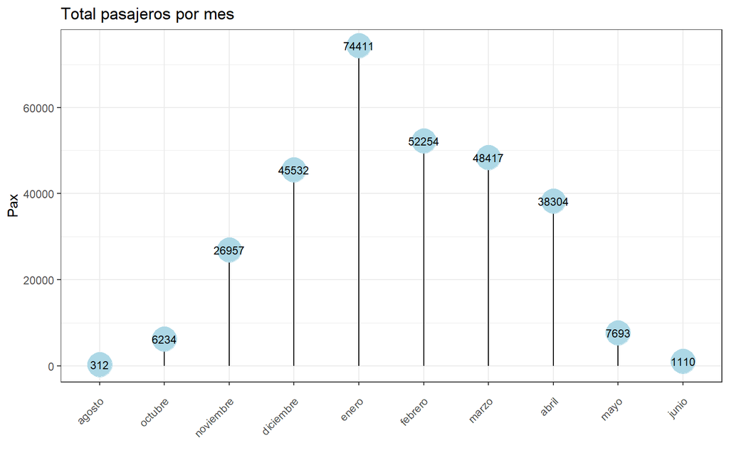

De manera análoga, se tiene el total de pasajeros. Note que existen meses donde la cantidad total de pasajeros aumenta. Respecto a esto, tenga presente los ciclos de venta de ticket de un crucero, que generalmente se realiza una reserva con un margen considerable de tiempo al compararlo con servicios de aerolíneas, por ejemplo.

## Gastos por pasajeros

La siguiente tabla muestra información pertinente respecto al gasto promedio por persona en los cruceros. Esto, sin categorizar por año.

| Tipo de pasajero | Número de pasajeros | Gasto promedio diario USD | Ingresos aproximados USD |
| --- | --- | --- | --- |
| Pasajeros | 424,734 | 122,43 | 52.000.183 |
| Tripulantes | 158,932 | 70.01 | 11.126.829 |

## Numero de recaladas por año

Se define recalada a la acción de un buque de llegar a puerto. Para el puerto se tiene lo siguiente:

[figure not shown]

## Sobre los pasajeros

Según los datos obtenidos de Citur, para entender el comportamiento de los cruceros; se tiene también datos acerca del tamaño de estos (Medida de ‘Eslora’) y la cantidad de pasajeros.

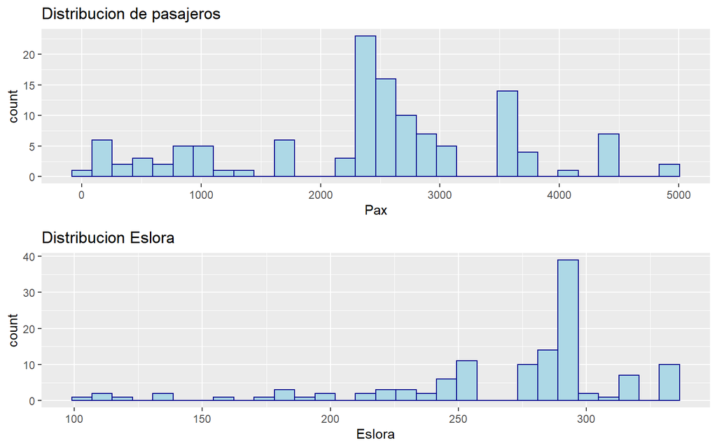

Dados estos datos, parece haber 3 categorías. Note que, en los gráficos, se “dividen” en tres grupos diferentes. un primer grupo, que maneja un menor número de pasajeros (entre 0 y 1000 pasajeros)

El siguiente grupo, entre los 2000 pasajeros y menos de 4 mil.

El tercer grupo, más de 4 mil pasajeros.

Este análisis es consistente con relación a la distribución de la Eslora; donde tambien se ve segregado 3 grandes grupos. Esloras pequeñas, medianas y grandes.

# Análisis de mercado para el 2021

Se tiene un total del número de barcos registrados en el puerto de Cartagena para el año 2021.

| Barcaza | Bongo | Cargueros | Fragata | Otras embarcaciones menores | Pesquero | Portacontenedores | Remolcador | Turismo | Roll on Roll of | Mixto | 2021 |
| --- | --- | --- | --- | --- | --- | --- | --- | --- | --- | --- | --- |
| 504 | 555 | 245 | 9 | 3 | 7 | 2003 | 181 | 22 | 53 | 4 | 3586 |

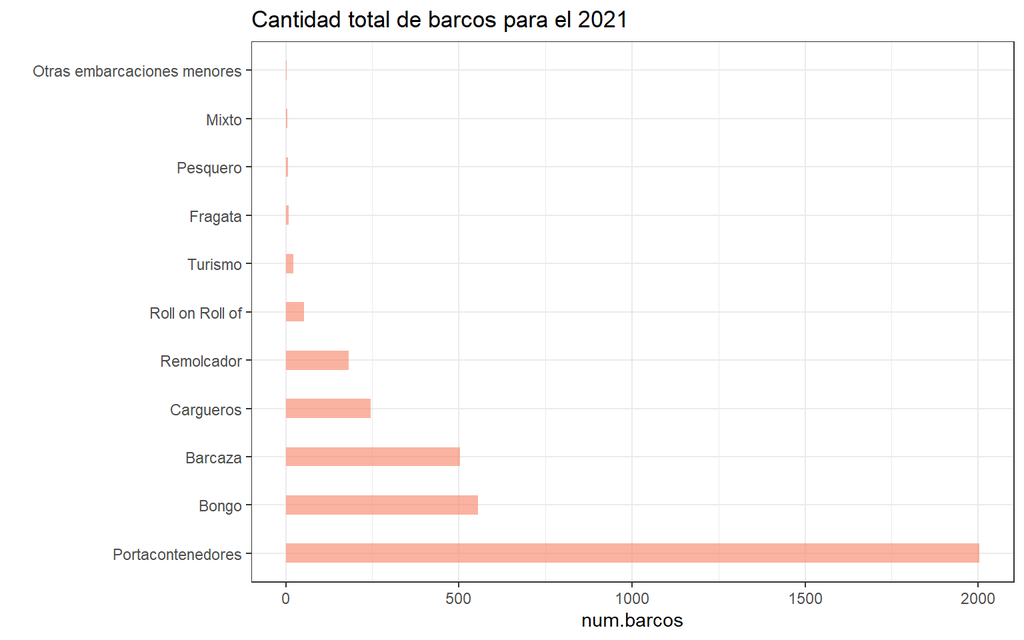

El número total de cruceros (Categoría Turismo) que se tiene para este año representa menos del 1% de la cantidad totales de embarcaciones que llegan a el puerto.

# Análisis de mercado

Para el año 2022 se tiene la siguiente información hasta mayo.

| Barcaza | Bongo | Cargueros | Pesquero | Portacontenedores | Remolcador | Roll on Roll of | Turismo | Cabotaje especial | Fragata | Mixto | Otras embarcaciones menores | 2022 |
| --- | --- | --- | --- | --- | --- | --- | --- | --- | --- | --- | --- | --- |
| 300 | 93 | 54 | 1 | 582 | 65 | 8 | 56 | 1 | 2 | 1 | 18 | 1181 |

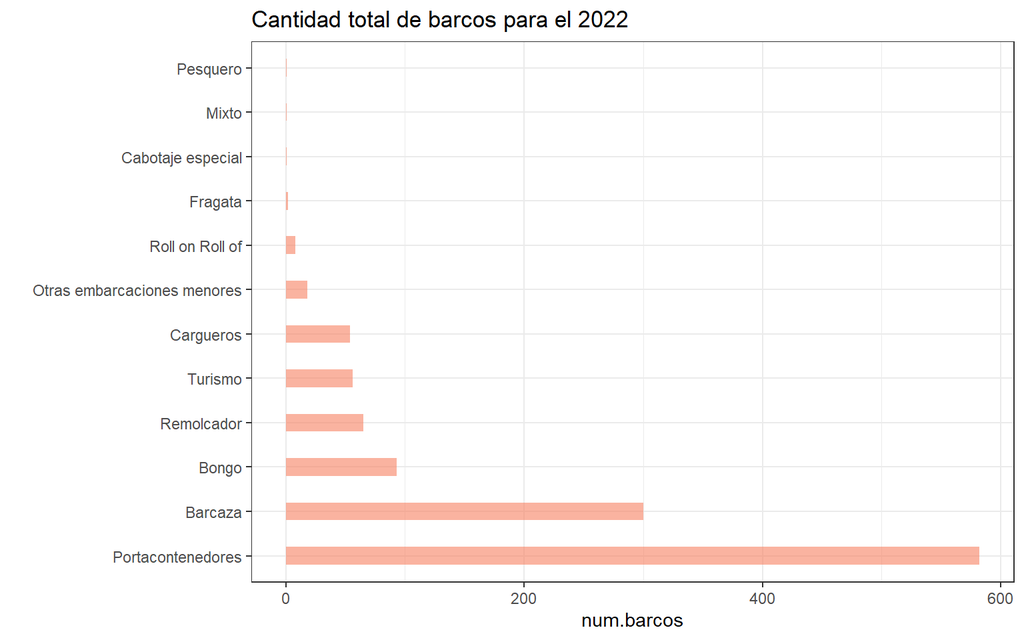

El comportamiento general del tipo de embarcaciones no ha cambiado de un año a otro. Note que para el año 2022 (solo hasta mayo) se nota un incremento considerable en la cantidad de barcos que llegan. Esto es dado el efecto del COVID, puesto que para todo el año 2021 se tiene registro de 22 barcos turísticos en el puerto; lo que contrasta con el total obtenido hasta mayo en el 2022, un total de 56 barcos.

# Precio promedio ticket

Para el cálculo del precio promedio, se realiza un muestreo de los datos de diferentes páginas web en las cuales se extrae la información del respectivo ticket de un crucero en función de la categoría. Así, se tiene que:

Las siguientes tablas presentan el valor promedio de un ticket en función de la categoría. En los cruceros, existen varias categorías de tickets (habitaciones) a reservar. En este caso, el ticket más básico ofrece una habitación sencilla en la embarcación. La segunda categoría ofrece habitación con ventana, la tercera, habitación con balcón y finalmente la categoría más alta es la suite. Para realizar estos cálculos se realiza un muestreo general para entender el comportamiento de estos precios. La primera tabla entrega los valores promedios de dichos tickets. Este es el valor que se esperaría que tomen los tickets en estas categorías. La segunda tabla, presenta lo que se denominan “Intervalos de confianza”; abreviados como IC. Estos últimos se utilizan para dar un comportamiento general de la variabilidad. En pocas palabras, la primera línea presenta el valor inferior mínimo que puede tomar un ticket de una categoría dada. La segunda línea de la tabla presenta el valor máximo que puede tomar dicho ticket.

|  | Estandar | Estandar_ventana | Balcon | Suite |
| --- | --- | --- | --- | --- |
| mean of x | 1401.143 | 1529.571 | 2273.143 | 3045.571 |

| IC Estandar | IC Estandar_ventana | IC Balcon | IC Suite |
| --- | --- | --- | --- |
| 747.8197 | 747.0219 | 1352.976 | 1802.203 |
| 2054.4660 | 2312.1210 | 3193.310 | 4288.940 |

# Referencias

1. https://www.puertocartagena.com/sites/default/files/inline/infografia-reactivacion-cruceros-porticolive_compressed_1.pdf
2. https://www.puertocartagena.com/es/descargables-informativos
3. https://www.cruceros.co/pd-4-cartagena-de-indias
4. https://portucolombia.mincit.gov.co/tematicas/estadisticas-territoriales-de-turismo-1
5. https://deluxetravel.com.co/cotizar-cruceros/